**Link to colab:** https://colab.research.google.com/drive/1yXUXyFhPzg8xsJ5DHnyScGyFoJfa9dOc

**Link to html version (better view than PDF file):** https://raw.githack.com/michaeldybdahl/M2_miniassignements/master/Copy%20of%20M2_1st%20assignment.html

I recommend to use the HTML version, because there are still some weird overlaps with the pages in the PDF file.

# Load of packages

Here I start by loading all the packages that I proably are going to use in the notebook.

```r
### Generic preamble
Sys.setenv(LANG = "en") # For english language
options(scipen = 5) # To deactivate annoying scientific number notation
set.seed(1337) # To have a seed defined for reproducability

### Knitr options
if (!require("knitr")) install.packages("knitr"); library(knitr) # For display of the markdown
knitr::opts_chunk$set(warning=FALSE,
                     message=FALSE,
                     fig.align="center"
                     )

### Install packages if necessary
if (!require("pacman")) install.packages("pacman") # package for loading and checking packages :)
pacman::p_load(tidyverse, # Standard datasciewnce toolkid (dplyr, ggplot2 et al.)
               magrittr, # For advanced piping (%>% et al.)
               igraph, # For network analysis
               tidygraph, # For tidy-style graph manipulation
               ggraph, # For ggplot2 style graph plotting
               Matrix, # For some matrix functionality
               data.table # For fast table manipulations (and fread)
               )
```

# Load the data

Here I load the three edgelistes and the nodelist.

I use "fread" to load the edgelist, because they are formatted as textfiles.

```r
advice <- fread("https://raw.githubusercontent.com/SDS-AAU/M2-2019/master/notebooks/assignments/assignment_1/data/Krack-High-Tec-edgelist-Advice.txt")
friendship <- fread("https://raw.githubusercontent.com/SDS-AAU/M2-2019/master/notebooks/assignments/assignment_1/data/Krack-High-Tec-edgelist-Friendship.txt")
report_to <- fread("https://raw.githubusercontent.com/SDS-AAU/M2-2019/master/notebooks/assignments/assignment_1/data/Krack-High-Tec-edgelist-ReportsTo.txt")

nodes <- read_csv("https://raw.githubusercontent.com/SDS-AAU/M2-2019/master/notebooks/assignments/assignment_1/data/Krack-High-Tec-Attributes.csv")
```

# 1. Create a network

The three text matrices does not have coloumn names and therefor I add this using "colnames". This is maybe a bit unneccesary, but I like that the coloumnnames has a meaning ;-)

```r
colnames(advice) <- c("ID", "alter", "presence")
colnames(friendship) <- c("ID", "alter", "presence")
colnames(report_to) <- c("ID", "alter", "presence")
```

Now I only want the edgelistes to contain edges that has 1 in presence, for example if there are are advice between to ID's (managers), then presence is 1. Else I would just get the same edges for alle three edgelist.

```r
advice <- advice %>%
  filter(presence == 1)

friendship <- friendship %>%
  filter(presence == 1)

report_to <- report_to %>%
  filter(presence == 1)
```

## 1.1. Generate network objects

Here I start by loading the three different type of edges (advice, friendship, report to) into isolated networks.

```r
g_advice <- graph_from_data_frame(d = advice, directed = TRUE, vertices = nodes)
g_friendship <- graph_from_data_frame(d = friendship, directed = TRUE, vertices = nodes)
g_report_to <- graph_from_data_frame(d = report_to, directed = TRUE, vertices = nodes)
```

```r
g_advice <- g_advice %>%
  as_tbl_graph() %E>%
  mutate(type = "advice")

g_friendship <- g_friendship %>%
  as_tbl_graph() %E>%
  mutate(type = "friendship")

g_report_to <- g_report_to %>%
  as_tbl_graph() %E>%
  mutate(type = "report to")
```

```r
g_friendship
```

```
# A tbl_graph: 21 nodes and 102 edges
#
# A directed simple graph with 1 component
#
# Edge Data: 102 x 4 (active)
   from    to presence type
  <int> <int>    <int> <chr>
1     1     2        1 friendship
2     1     4        1 friendship
3     1     8        1 friendship
4     1    12        1 friendship
5     1    16        1 friendship
6     2     1        1 friendship
# … with 96 more rows
#
# Node Data: 21 x 5
  name    AGE TENURE LEVEL  DEPT
  <chr> <dbl>  <dbl> <dbl> <dbl>
1 1        33   9.33     3     4
2 2        42  19.6      2     4
3 3        40  12.8      3     2
# … with 18 more rows
```

# 2. Analysis

## 2.A. Network level characteristics

**Density:**

Here I use the "edge_density" function in the three edgelistes.

```r
edge_density(g_advice)
edge_density(g_friendship)
edge_density(g_report_to)
```

0.452380952380952

0.242857142857143

0.0476190476190476

45,24% seek **advice** of possible connections in the network.

24,29% seek **friendship** of possible connections in the network.

They **report to** 4,76% of possible connections in the network.

**Are the employees generally more likely to be in a friendship or advice-seeking relationship?**

Yes, indeed. This makes sence, because of course the managers does not report to as many colleagues as they have friends- or advice relationship with.

```r
transitivity(g_advice, type = "global")
transitivity(g_friendship, type = "global")
transitivity(g_report_to, type = "global")
```

0.734508816120907

0.471494607087827

0

**Are friends of your friends also your friends?**

Yes, to some extent (transitivity = 0.47). So some friends of your friends, is also your friends.

```r
reciprocity(g_advice)
reciprocity(g_friendship)
reciprocity(g_report_to)
```

0.473684210526316

0.450980392156863

0

**Are relationships like friendship and advice giving usually reciprocal?**

If you look advice or have a friendship with a employee, they are also more likely to seek advice or have a friendship with you.

If you report to one, then they dont also report to you, which of course makes sence, because the person you report to is likely your manager.

## 2.B: Node level characteristics

**Adding centrality degree to the three network graphs.**

Here I add centrality degree to each network and I set the mode to "in", because I want the edge that comes in to the node, fx who get advice, who get friends and who are reported to.

```r
g_advice <- g_advice %N>%
  mutate(centrality_dgr_out_advice = centrality_degree(mode = "out"))
# I set mode = "out", because I consider advice relationship, that you give out advices.

g_friendship <- g_friendship %N>%
  mutate(centrality_dgr_in_friendship = centrality_degree(mode = "in"))

g_report_to <- g_report_to %N>%
  mutate(centrality_dgr_in_report_to = centrality_degree(mode = "in"))
```

**Who is the most wanted friend?**

Here I print the head of the friend network as tibble and arrange it with descending centrality degree (so I get the person with highest friends in the top).

```r
g_friendship %N>%
  as_tibble() %>%
  head(3) %>%
  arrange(desc(centrality_dgr_in_friendship))
```

A tibble: 3 × 6

| name <chr> | AGE <dbl> | TENURE <dbl> | LEVEL <dbl> | DEPT <dbl> | centrality_dgr_in_friendship <dbl> |
| --- | --- | --- | --- | --- | --- |
| 2 | 42 | 19.583 | 2 | 4 | 10 |
| 1 | 33 | 9.333 | 3 | 4 | 8 |
| 3 | 40 | 12.750 | 3 | 2 | 5 |

I can see that the person with ID 2, is the most wanted friend, where 10 has him/her as a friend.

This have I also plotted below, where you can se how ID 2 and 1 have the most edges going into them (friends).

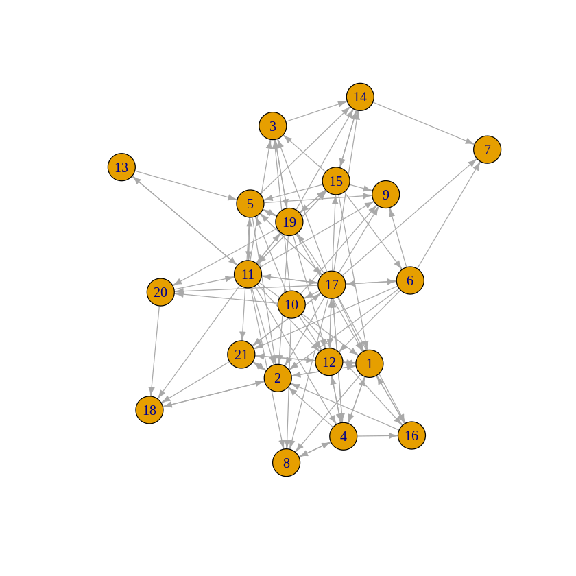

```r
plot(g_friendship,
    edge.arrow.size = 0.5)
```

**Who is the most ""wanted" advice giver?**

```r
g_advice %N>%
  as_tibble() %>%
  head(3) %>%
  arrange(desc(centrality_dgr_out_advice))
```

A tibble: 3 × 6

| name <chr> | AGE <dbl> | TENURE <dbl> | LEVEL <dbl> | DEPT <dbl> | centrality_dgr_out_advice <dbl> |
| --- | --- | --- | --- | --- | --- |
| 3 | 40 | 12.750 | 3 | 2 | 15 |
| 1 | 33 | 9.333 | 3 | 4 | 6 |
| 2 | 42 | 19.583 | 2 | 4 | 3 |

So ID 3 is the person who is giving most advices out, which we also can see in the plot below (though it can be harder to see where the arrows are going).

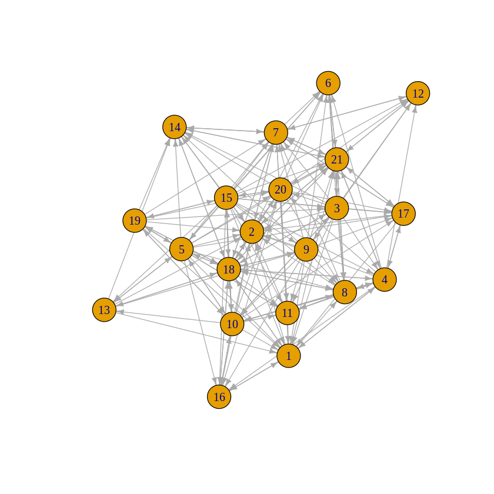

```r
plot(g_advice,
    edge.arrow.size = 0.5)
```

**Are managers in higher hirarchy more popular as friend?**

Here I will summarize the mean of the centrality degree, and I group it by "LEVEL", so I get the mean for each Level hirarchy.

```r
g_friendship %N>%
  as_tibble() %>%
  group_by(LEVEL) %>%
  summarize(mean = mean(centrality_dgr_in_friendship))
```

A tibble: 3 × 2

| LEVEL <dbl> | mean <dbl> |
| --- | --- |
| 1 | 3.0000 |
| 2 | 6.0000 |
| 3 | 4.6875 |

I can see that the level 2 (vice presidents) are the most popular as friend with average 6 as friend and the CEO (level) is the the least popular as friend with average 3.

This I want to plot and visualize with the nodes colored by the LEVEL.

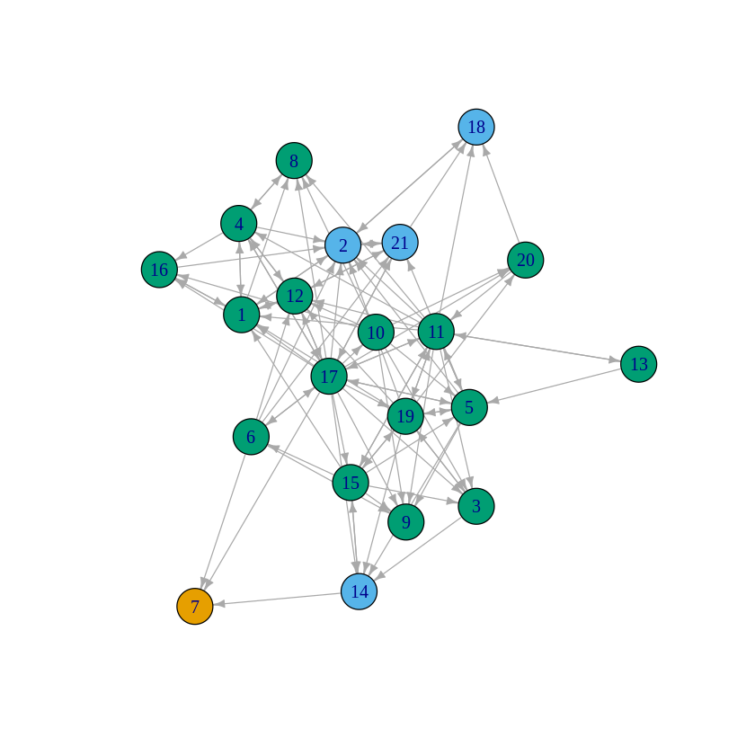

```r
plot(g_friendship,
    edge.arrow.size = 0.5,
    vertex.color = as.numeric(factor(V(g_friendship)$LEVEL)))
```

The plot does not show which color is which level and therefore I want to print the ID for each color, where I chose ID: 1,2 & 7.

```r
g_friendship %N>%
  as_tibble() %>%
  filter(name == 1|name == 2 |name == 7)
```

A tibble: 3 × 6

| name <chr> | AGE <dbl> | TENURE <dbl> | LEVEL <dbl> | DEPT <dbl> | centrality_dgr_in_friendship <dbl> |
| --- | --- | --- | --- | --- | --- |
| 1 | 33 | 9.333 | 3 | 4 | 8 |
| 2 | 42 | 19.583 | 2 | 4 | 10 |
| 7 | 55 | 30.000 | 1 | 0 | 3 |

Calling as tibble and filtering with ID 1,2 and 7, we can see that:

1 = Level 3 (managers)

2 = Level 2 (vice presidents)

**Are managers in higher hirarchy more popular as advice giver?:**

```r
g_advice %N>%
  as_tibble() %>%
  group_by(LEVEL) %>%
  summarize(mean = mean(centrality_dgr_out_advice))
```

A tibble: 3 × 2

| LEVEL <dbl> | mean <dbl> |
| --- | --- |
| 1 | 8.0000 |
| 2 | 8.7500 |
| 3 | 9.1875 |

Here I can see that the managers in lower hirarchy is more "popular" as advice giver and the person who gave 15 advices from earlier, was also from the lowest level (3).

## 2.C. Relational Characteristics

**Are managers from the same 1. department, or on the same 2. hirarchy, 3. age, or 4. tenuere more likely to become friends or give advice? (hint: assortiativity related)**

**1. Are managers from the same *department* more likely to become friends or give advice?**

```r
assortativity(g_friendship, V(g_friendship)$DEPT, directed = TRUE)
```

0.151157711410702

So managers are not so much likely to become friends with managers from same department.

```r
assortativity(g_advice, V(g_advice)$DEPT, directed = TRUE)
```

0.107587088130058

Apparently managers doesnt give advice to so many in their own department, which is might a bit surprising.

**2. Are managers from the same *hirarchy* more likely to become friends or give advice?**

```r
assortativity(g_friendship, V(g_friendship)$LEVEL, directed = TRUE)
```

0.259244657047721

So the managers are in a certain extent more likely to become friends at same hirarchy/LEVEL as them self, but still not so much.

```r
assortativity(g_advice, V(g_advice)$LEVEL, directed = TRUE)
```

0.0553974479997201

Managers are much likely **not** to give managers at same hirarchy advice, which makes sence, that the managers probably give advice to employees at a lower hirarchy/level.

**3. Are managers from the same *age* more likely to become friends or give advice?**

```r
assortativity(g_friendship, V(g_friendship)$AGE, directed = TRUE)
```

0.10028705775003

This is a bit surprising, that managers with the same age are not much more likely to become friends, where I would expect it to be much higher. But that just conclude that the managers are friends with different ages.

Maybe this coefficent can be caused that the age interval is not that wide.

```r
assortativity(g_advice, V(g_advice)$AGE, directed = TRUE)
```

0.0387598006439393

**Are friends more likely to give each others advice?**

```r
assortativity(g_advice, V(g_friendship)$centrality_dgr_in_friendship, directed = TRUE)
```

-0.0881102077099041

Not at all. So the managers wont give their friends advices.

# 3. Aggregated Networks

## 3.1. Aggregated advice network

I start by creating a new node list, that only contain the departments as nodes (= 5 nodes)

```r
nodes_agg <- nodes %>%
  group_by(DEPT) %>%
  summarize(ID = n()) # I summarize so I only get a row for each department
                      # the fact that I summarize by size of ID is not important.
```

```r
nodes_agg
```

A tibble: 5 × 2

| DEPT <dbl> | ID <int> |
| --- | --- |
| 0 | 1 |
| 1 | 5 |
| 2 | 8 |
| 3 | 3 |
| 4 | 4 |

I create "nodes4join" as new dataframe, because I need this to left_join the ID for both "ID"(from) and "alter" (to) in the aggregated edgelist.

Here I only select ID and DEPT, because I dont need the other attributes.

```r
nodes4join <- nodes %>%
  select(ID, DEPT)
```

Now I use "left_join" to get the DEPT number for both the "ID"(from) and "alter"(to) edges.

```r
g_advice_agg <- advice %>%
  left_join(nodes4join, by = c("ID" = "ID")) %>%
  left_join(nodes4join, by = c("alter" = "ID"))
```

```r
head(g_advice_agg)
```

A data.frame: 6 × 5

| ID <dbl> | alter <dbl> | presence <int> | DEPT.x <dbl> | DEPT.y <dbl> |
| --- | --- | --- | --- | --- |
| 1 | 2 | 1 | 4 | 4 |
| 1 | 4 | 1 | 4 | 4 |
| 1 | 8 | 1 | 4 | 1 |
| 1 | 16 | 1 | 4 | 4 |
| 1 | 18 | 1 | 4 | 3 |
| 1 | 21 | 1 | 4 | 1 |

I rearrange the the coloumn order in the edgelist, because I need the DEPT.x (from) and DEPT.y (to) as edges and therefor to be first in the edgelist.

```r
g_advice_agg <- g_advice_agg[c("DEPT.x", "DEPT.y", "ID", "alter", "presence")]
```

Now I transform the edgelist from dataframe to a graph object.

```r
g_advice_agg <- graph_from_data_frame(d = g_advice_agg, directed = TRUE, vertices = nodes_agg)
```

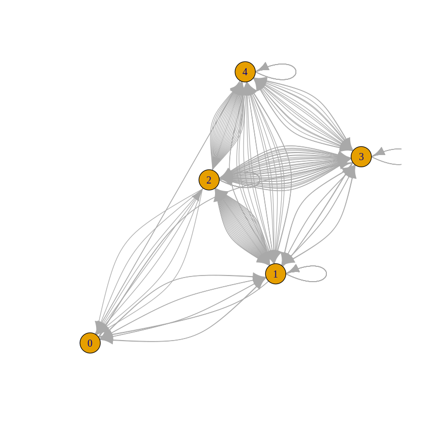

```r
plot(g_advice_agg)
```

In the plot, we can see that department 2 has alot of advice relationships, and department 0 (the CEO) has nearly none. We can see that department 2 fx has alot advice to department 4, but this department does not give alot advices back to department 2 (probably because department 4 are on lower level than department 2).

## 3.2. Aggregated friendship network

Now I will do the same as in part 3.1, just with the friendship network.

```r
nodes_agg_f2 <- nodes %>%
  select(ID, DEPT)
```

```r
g_friendship_agg <- friendship %>%
  left_join(nodes_agg_f2, by = c("ID" = "ID")) %>%
  left_join(nodes_agg_f2, by = c("alter" = "ID"))
```

```r
g_friendship_agg <- g_friendship_agg[c("DEPT.x", "DEPT.y", "ID", "alter", "presence")]
```

```r
g_friendship_agg <- graph_from_data_frame(d = g_friendship_agg, directed = TRUE, vertices = nodes_agg)
```

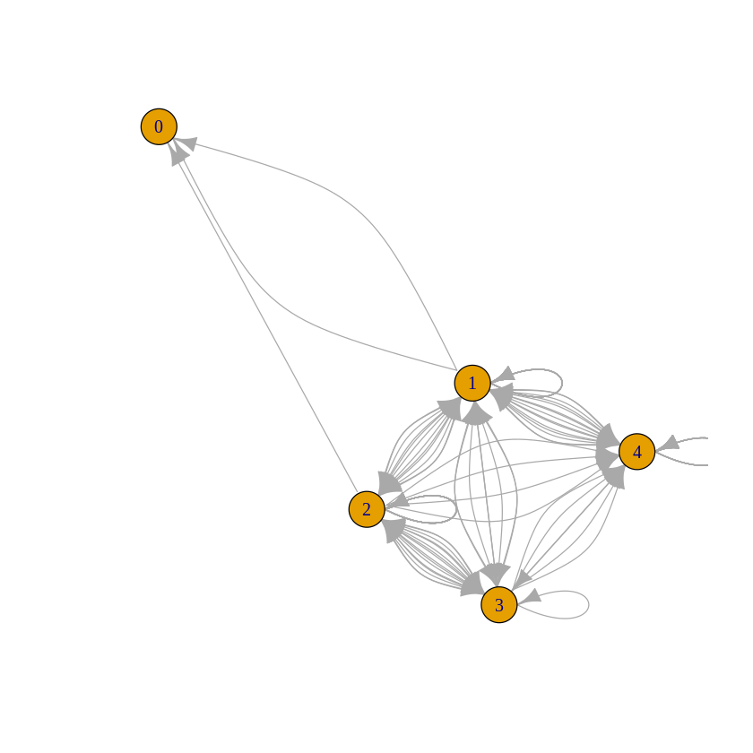

```r
plot(g_friendship_agg)
```

We can see in the plot, that department 0 (CEO) has 3 friends from department 1 and 2, but he doesnt see them as his/her friend.

Below here, I make the same plot, just where the node/vertex size is the degree of the friendship, where department 1,2 and 4 seem to be around equal popular across departmens, where department 3 has a bit lower degree.

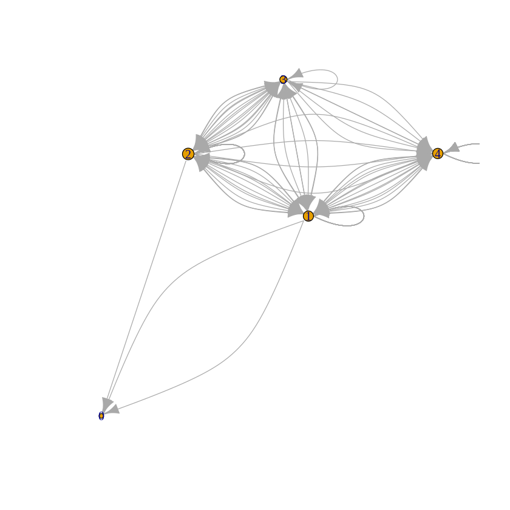

```r
plot(g_friendship_agg,
     vertex.size = 1+ sqrt(degree(g_friendship_agg, mode = "in")))
```

# 4. Visualization

I did the visualization during the analysis (part 2) and aggregated networks (part 3).

## 4.1. Visualization of friendships across hirarchy/LEVEL

In section 2.C., I saw that managers from the same hirarchy was in a certain extent, more likely to became friends - but still not that much (assortativity = 0.25).

Below I want to visualize this with a plot of the friendship network, that color the nodes by their LEVEL.

I also plot the size of the nodes as the centrality degree, so I can see the nodes (managers) with a high degree of friends.

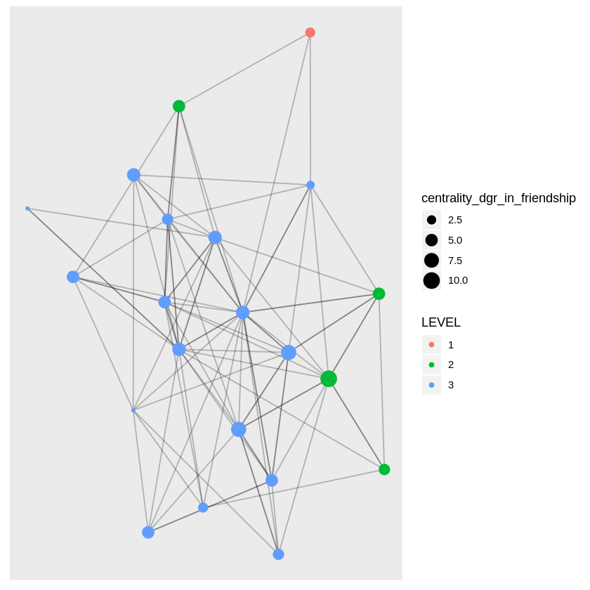

```r
g_friendship %>%
  mutate(LEVEL = as.factor(LEVEL)) %>% # the color aesthetic need to be categorical and therefor I factor LEVEL.
         ggraph(layout = 'nicely') +
  geom_edge_link(alpha = 0.25) +
  geom_node_point(aes(size = centrality_dgr_in_friendship,
                      color = LEVEL))
```

As we can see, their are some sort of cluster by the level of the managers, but it is probably just because there are so many managers from the LEVEL 3 hirarchy.

Also there are only 1 CEO (level 1) and therefore he could of course not only be friend with that same level - unless he does not have any that sees him as friend (which 3 does).

## 4.2. Visualization of friendships across departments

Here I do the same as before, just where I color the nodes with the departments.

In section 2.C, I saw that there was not a high assortativity between friendships and departments (assortativity = 0.1). So In this plot, I also expect the colors not be cclearly clustered.

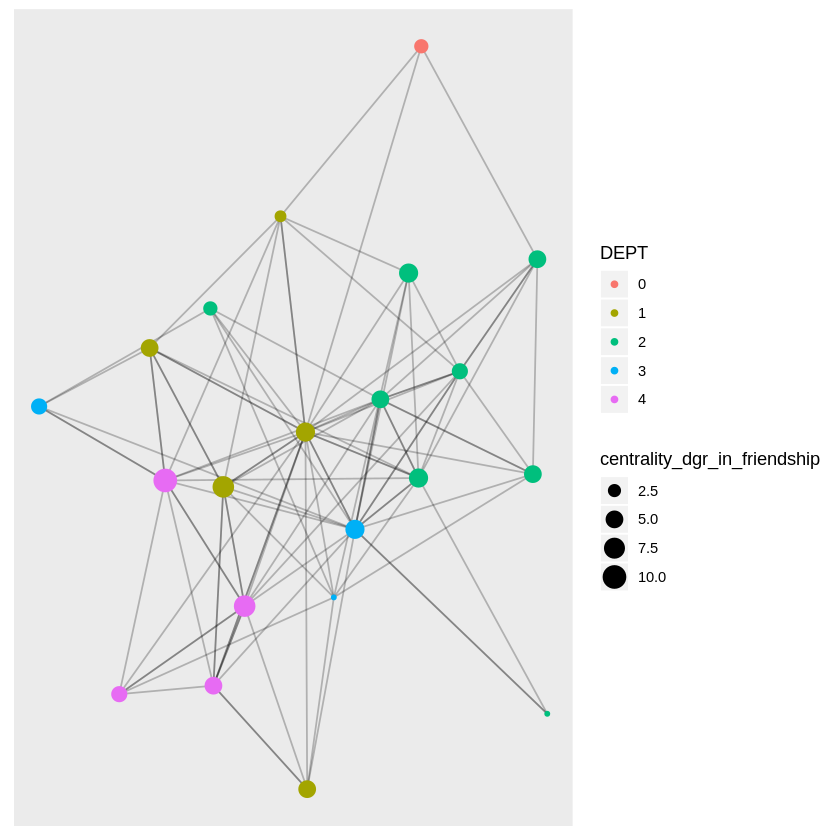

```r
g_friendship %>%
  mutate(DEPT = as.factor(DEPT)) %>% # the color aesthetic need to be categorical and therefor I factor DEPT.
         ggraph(layout = 'nicely') +
  geom_edge_link(alpha = 0.25) +
  geom_node_point(aes(size = centrality_dgr_in_friendship,
                      color = DEPT))
```

The plot shows us that there are some degree of clustered friendships between the departments, although a manager from department 1, seem to be have friends in all the other departments.

Below I made the same plot, just where I added arrows, so we can see where the edge is directed.

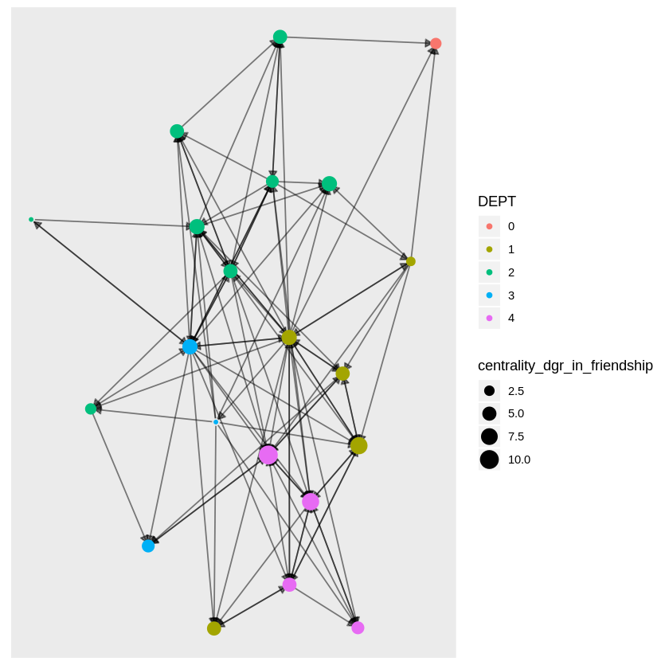

```r
g_friendship %>%
  mutate(DEPT = as.factor(DEPT)) %>% # the color aesthetic need to be categorical and therefor I factor DEPT.
         ggraph(layout = 'nicely') +
  geom_edge_link(arrow = arrow(type = "closed", length = unit(2, "mm")),
                start_cap = circle(1, "mm"),
                end_cap = circle(1, "mm"),
                alpha = 0.5) +
  geom_node_point(aes(size = centrality_dgr_in_friendship,
                      color = DEPT))
```

Here we fx can see that the small nodes (those with low degree of centrality), does not have many arrows against them. So this also shows if the manager is not that popular (has many that see them as a friend) - just like the size.

# 5.

[figure not shown]